# SVM

AUTEUR Celeste Esteban

2023-11-05

## Un SVM, mais pour quoi faire ?

Le SVM (Support Vector Machine ou Machine à vecteurs de support) est un **algorithme d’apprentissage automatique supervisé** qui peut être utilisé pour résoudre des problèmes de **classification** ou de régression.

Le principe des SVM consiste à ramener un problème de classification ou de discrimination à un hyperplan (feature space) dans lequel les données sont séparées en plusieurs classes, la frontière de séparation étant la plus éloignée possible des points de données (ou marge maximale).

Prenons un exemple simple de classification pour mieux comprendre de quoi il s’agit. Supposons une population composée de 50% de femmes et 50% d’hommes. En utilisant un échantillon de cette population, nous souhaitons créer un ensemble de règles qui nous guideront dans la classification des sexes pour le reste de la population.

## Chargement des données :

**TOUTES LES DONNÉES ONT ÉTÉ ANONYMISÉES ET NE CONTIENNENT AUCUNE DONNÉE A CARACTÈRE PERSONNEL, ET LEURS CONFORMITÉ AU RGPD EST ASSURÉE**  
*Une donnée à caractère personnel est une information qui permet d’identifier un être humain (personne physique), directement (par exemple son nom/prénom), ou indirectement (par exemple son numéro de téléphone, son numéro de contrat, son pseudonyme).*

```r
BVCM = read.csv2(file = "BVCM.csv", header = TRUE, sep = ';', dec = ',', stringsAsFactors = TRUE)
dim(BVCM)
```

```
## [1] 2045   26
```

On importe les données depuis un fichier CSV. La fonction *“dimension”* nous apprend que le jeu de données contient **26 variables** pour **2045 lignes**.  
Le jeu de données est issue d’une base de données contenant les victimes corporelles médianes de sociétés dans le domaine de l’assurance.

Nous allons construire le modèle SVM à partir de 10 variables réunies dans le jeu de données *“BVCMQuanti”*. Ces variables sont les suivantes :

```
##  [1] "Rente _V" "Rente _T" "Age"      "Revenu"   "AIPP"     "Rea"
##  [7] "Chiru"    "Hospi"    "Crf"      "Arret"
```

Pour chaque variable, nous allons examiner leurs caractéristiques et leurs répartitions à partir des éléments ci-dessous. Cela s’inscrit dans une démarche de compréhension de nos variables, afin que plus tard nous puissions construire notre modèle SVM en toute connaissance :

- La valeur minimum
- La valeur du premier quantile
- La médiane
- La moyenne
- Le troisième quartile
- La valeur maximum

```r
summary(BVCMQuanti,digits = 1)
```

```
##     Rente _V     Rente _T       Age           Revenu           AIPP
##  Min.   : 1   Min.   : 0   Min.   : 0.8   Min.   :0e+00   Min.   :   0
##  1st Qu.:20   1st Qu.: 0   1st Qu.:31.0   1st Qu.:0e+00   1st Qu.:  10
##  Median :32   Median : 0   Median :46.0   Median :1e+04   Median :  15
##  Mean   :33   Mean   :11   Mean   :46.3   Mean   :2e+04   Mean   :  59
##  3rd Qu.:45   3rd Qu.:21   3rd Qu.:59.2   3rd Qu.:2e+04   3rd Qu.:  25
##  Max.   :98   Max.   :68   Max.   :94.0   Max.   :1e+07   Max.   :4125
##       Rea            Chiru          Hospi          Crf          Arret
##  Min.   :  0.0   Min.   :   0   Min.   :  0   Min.   :  0   Min.   :-43528
##  1st Qu.:  0.0   1st Qu.:   0   1st Qu.:  0   1st Qu.:  0   1st Qu.:     0
##  Median :  0.0   Median :   0   Median :  0   Median :  0   Median :   142
##  Mean   :  0.9   Mean   :   9   Mean   :  5   Mean   : 15   Mean   :   722
##  3rd Qu.:  0.0   3rd Qu.:   0   3rd Qu.:  0   3rd Qu.:  0   3rd Qu.:   640
##  Max.   :150.0   Max.   :3827   Max.   :618   Max.   :942   Max.   :778468
```

Les variables du jeu de donnée sont les suivantes :

- *Rente_V* : Euros de rente viagère liée au dossier
- *Rente_T* : Euros de rente temporaire liée au dossier
- *Age* : Âge à l’accident de la victime
- *Revenu* : Revenu annuel net de la victime avant l’accident
- *AIPP* : Taux d’atteinte permanente à l’intégrité physique et/ou psychique de la victime après l’accident
- *Rea* : Nombre de jours passé en réanimation par la victime
- *Chiru* : Nombre de jours passés en Chirurgie par la victime
- *Hospi* : Nombre de jours passés en hospitalisation par la victime
- *Crf* : Nombre de jours passés en CRF par la victime
- *Arret* : Nombre de jours d’arrêt de travail actuel de la victime

Dans le cadre de notre démarche visant à comprendre nos variables, nous créons des histogrammes pour représenter la répartition des individus pour chacune de nos 10 variables :

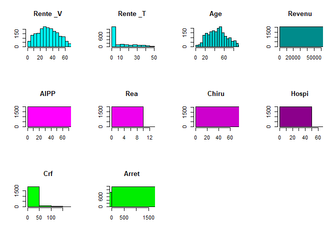

Enfin on réalise ces diagrammes en boîtes à moustache de chaque variable en fonction du montant total binaire du dossier (Chère ou Pas chère). Une fois de plus cela nous permet de mieux comprendre nos données afin de réaliser le modèle le plus performant possible.

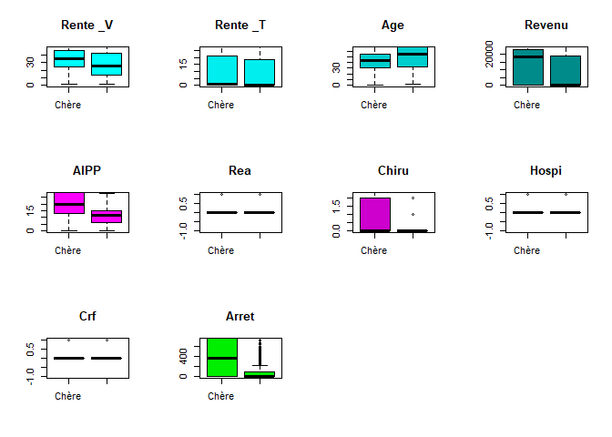

La séparation de la population en deux selon si le dossier a couté *“Chère”* (montant supérieur à 150k euros) ou *“Pas chère”* (montant inférieur à 150k euros) nous permet de détecter des corrélations. Par exemple, la variable AIPP se comporte différemment selon le coût du dossier. En effet, la valeur de l’AIPP est plus élevée en moyenne lorsque le dossier est “Chère”. Veuillez consulter l’Analyse en Composantes Principales (ACP) sur ces mêmes variables, disponible aussi sur mon GitHub.

## 1er modèle SVM à partir de la totalité des individus

```
##
## Call:
## svm.default(x = BVCMQuanti, y = BVCMQuali, scale = F, kernel = "radial",
##     cost = 1, probability = TRUE)
##
##
## Parameters:
##    SVM-Type:  C-classification
##  SVM-Kernel:  radial
##        cost:  1
##
## Number of Support Vectors:  2004
```

Les paramètres choisis pour ce premier modèle SVM sont les suivants :

- Noyau = “radial” : Notre cas semble être difficile à séparer linéairement. On opte ici pour un noyau radial.
- Scale = “F” : Pour que nos individus ne soient utilisés qu’une fois dans l’apprentissage
- Cost = “1” : Le coût des violations de contrainte permet de plus ou moins sanctionner les individus mal classés. Ici 1 (qui est le paramètre par defaut) offre de bonnes performances.

L’indice *“number of support vectors”* doit être petit par rapport au nombre d’individus. Un nombre de support vectors égale ou proche du nomnbre d’individus signifie que chaque individu a été sur-appris et aucune généralisation n’est possible.

Maintenant que le modèle est entraîné, nous allons le tester sur le même jeu de données et mesurer sa performance de prédiction à travers une matrice de confusion. L’exercice ici consiste pour le modèle à reprendre chaque individu en “cachant” le montant du dossier. C’est-à-dire qu’il ne dispose que des 10 variables paramètres du modèle pour prédire si le dossier est *“Chère”* ou *“Pas chère”*. Une fois qu’il a prédit le montant de tous les dossiers, il compare le prix réel du dossier avec celui qu’il avait prédit.

```r
Prediction1 <- predict(model1,BVCMQuanti,decision.values = TRUE,probability = TRUE)
```

```
##            Reference
## Prediction  Chère Pas chère
##   Chère      1339        30
##   Pas chère    13       663
```

Le tableau se lit comme suit :

|  | Chère | Pas chère |
| --- | --- | --- |
| Chère | Nb dossiers réellement Chère prédits Chère | Nb dossiers réellement Pas chère prédits Chère |
| Pas chère | Nb dossiers réellement Chère prédits Pas chère | Nb dossiers réellement Pas chère prédits Pas Chère |

Pour mesurer la performance de notre modèle regardons le pourcentage d’individus bien classé par rapport aux nombre de mal classés noté *“Accuracy”*:

```
##       Accuracy          Kappa  AccuracyLower  AccuracyUpper   AccuracyNull
##   9.789731e-01   9.527909e-01   9.717805e-01   9.847420e-01   6.611247e-01
## AccuracyPValue  McnemarPValue
##  2.530216e-291   1.468819e-02
```

Notre modèle prédit correctement la classe de prix de plus de 97% des dossiers ! C’est un excellent résultat, voir même un peu trop…

La démarche que je viens de vous exposer comporte une **faille**. Et c’est la suivante : **Les données qui servent à entraîner le modèle et les données qui servent à le tester sont les mêmes.** Après avoir pris conscience de ça, notre modèle perd en magie… Et oui, puisqu’on voudrait le féliciter d’avoir deviné la classe de prix des dossiers qu’il avait déjà vus lors de son apprentissage. On peut au moins le féliciter d’avoir bonne mémoire, mais pas de pouvoir prédire et généraliser ses connaissances !  
**Mais ne pouvons-nous pas aller plus loin ?** Et bien si ! La bonne nouvelle, c’est qu’il existe une super technique pour éviter le sur-apprentissage et pour tester notre modèle sur des données qui lui sont inconnues, ce qui nous permettra de le tester en conditions réelles et de voir quelles sont ses performances face à de vrais dossiers.

Et pour cela, rien de mieux que le hasard…

## 2ème modèle SVM à partir d’une portion des individus connus

Cette deuxième méthode est bien plus réaliste et permettra de faire preuve de robustesse face aux nouveaux individus.

On commence par créer une liste de 800 valeurs aléatoires comprise entre 1 et 2045 (le nombre de lignes de notre jeu de données).

```r
Valeuralea =sample(size=800,1:2045)
```

Ces 800 valeurs aléatoires vont nous permettre d’extraire du jeu de données initial 800 individus pris aléatoirement (par exemple le 2, le 5, le 7, le 8 etc). Ces 800 individus tirés au hasard vont constituer nos données d’entraînement. Le modèle vas se construire à partir de ses 800 individus et on le testera sur les 2045 - 800 c’est à dire les 1 245 individus restants.

```
##
## Call:
## svm.default(x = Apprentissage_BVCMQuanti, y = Apprentissage_BVCMQuali$Apprentissage_BVCMQuali,
##     scale = F, kernel = "linear", degree = 1, coef0 = 1, cost = 1,
##     probability = TRUE)
##
##
## Parameters:
##    SVM-Type:  C-classification
##  SVM-Kernel:  linear
##        cost:  1
##
## Number of Support Vectors:  251
```

Maintenant que notre nouveau modèle est entraîné, nous allons effectuer les prédictions des montants sur les 1245 dossiers restants, tous inconnus pour lui :

```r
Prediction2 <- predict(model_alea1,Test_BVCMQuanti,decision.values = TRUE)
```

Comme précédemment, nous pouvons mesurer la performance de notre modèle à travers une matrice de confusion :

```r
CM2$table
```

```
##            Reference
## Prediction  Chère Pas chère
##   Chère       585       236
##   Pas chère    87       337
```

Pour rappel le tableau se lit comme suit :

|  | Chère | Pas chère |
| --- | --- | --- |
| Chère | Nb dossiers réellement Chère prédits Chère | Nb dossiers réellement Pas chère prédits Chère |
| Pas chère | Nb dossiers réellement Chère prédits Pas chère | Nb dossiers réellement Pas chère prédits Pas Chère |

Pour mesurer la performance de notre modèle regardons le pourcentage d’individus bien classé par rapport aux nombre de mal classés noté *“Accuracy”*:

```
##       Accuracy          Kappa  AccuracyLower  AccuracyUpper   AccuracyNull
##   7.405622e-01   4.676254e-01   7.152628e-01   7.647202e-01   5.397590e-01
## AccuracyPValue  McnemarPValue
##   2.535565e-48   1.796472e-16
```

[figure not shown]

Ici l’*“Accuracy”* du modèle est égale 0.7406

Notre modèle prédit correctement la classe de prix de plus de 74% des dossiers !

C’est un **bon résultat**, bien que ce soit moins que les 97% du modèle précédent, mais ce second modèle est en réalité **bien meilleur** car il est testé avec des dossiers qu’il n’a pas appris.

Voici ce qui pourrait tout de même amélioré la précision du modèle :

- Inclure des variables qui expliquent encore mieux le montant total du dossier
- Le choix du noyau
- Le choix du coût de violation des contraintes
- Le choix des paramètres du noyau

## Application de prédiction

J’ai programmé une **application** qui demande à un gestionnaire potentiel de remplir les valeurs des 10 variables du modèle. L’application renvoie ensuite, à partir du deuxième modèle, sa prédiction du montant pour les valeurs des paramètres renseignées.

[Lien vers mon application SVM](https://celeste-esteban.shinyapps.io/app1/)